# Parametrization of Earthworm Population Models

User

2024-12-08

## Introduction

This document provides a detailed parameterization of population models for earthworms, focusing on **Lumbricus terrestris** and **Eisenia fetida**. The models incorporate survival rates, reproduction rates, and the influence of environmental factors such as soil moisture and temperature.

## Model Framework

The population dynamics are modeled using discrete time steps with parameters for survival, reproduction, and environmental influence.

### Key Equations

The population size $N_t$ at time $t$ is governed by:

$$N_{t+1} = N_t \cdot S_t + B_t,$$

where: - $S_t$ is the survival rate. - $B_t$ is the number of new individuals (births).

The birth rate $B_t$ depends on reproduction rate $R$ and the number of mature individuals $M_t$:

$$B_t = M_t \cdot R.$$

Environmental factors (temperature $T$ and moisture $W$) modify $S_t$ and $R$:

$$S_t = S_{base} \cdot \exp\left(-\alpha \cdot |T - T_{opt}|\right) \cdot
\beta(W),$$

$$R = R_{base} \cdot \gamma(T, W).$$

## Parameters for Lumbricus terrestris

### Survival Rates

Example:

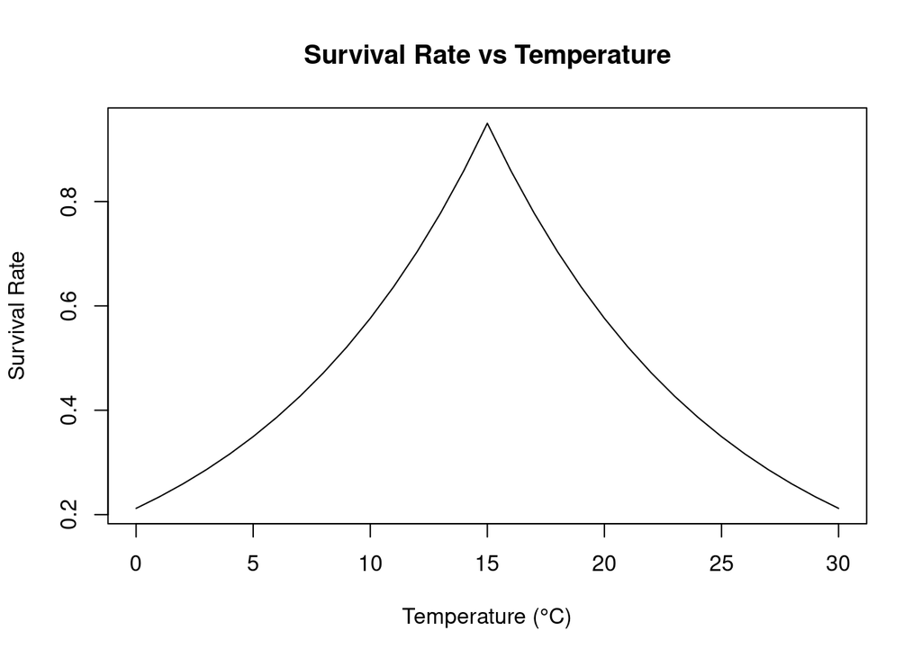

```r
T_opt <- 15
alpha <- 0.1
T <- seq(0, 30, by = 1)
S_base <- 0.95
S_t <- S_base * exp(-alpha * abs(T - T_opt))
plot(T, S_t, type = "l", xlab = "Temperature (°C)", ylab = "Survival Rate", main = "Survival Rate vs Temperature")
```

### Reproduction Rates

- Average cocoon production: 2 per week per mature individual.
- Hatching success: 50%.

```r
M_t <- 100 # Number of mature individuals
R_base <- 2 # Cocoons per week
hatching_success <- 0.5
B_t <- M_t * R_base * hatching_success
cat("Number of new individuals: ", B_t, "\n")
```

```
## Number of new individuals:  100
```

## Parameters for Eisenia fetida

### Survival Rates

- Optimal moisture: $60-80\%$.

Example:

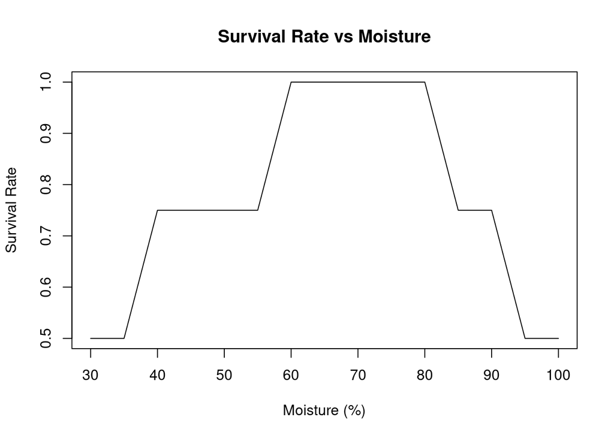

```r
W_opt <- 70
beta <- function(W) {
  if (W < 40 || W > 90) return(0.5)
  if (W >= 60 && W <= 80) return(1)
  return(0.75)
}
W <- seq(30, 100, by = 5)
S_t <- sapply(W, beta)
plot(W, S_t, type = "l", xlab = "Moisture (%)", ylab = "Survival Rate", main = "Survival Rate vs Moisture")
```

### Reproduction Rates

- Cocoons per week: 3.
- Hatching success: 80%.

```r
M_t <- 200 # Number of mature individuals
R_base <- 3 # Cocoons per week
hatching_success <- 0.8
B_t <- M_t * R_base * hatching_success
cat("Number of new individuals: ", B_t, "\n")
```

```
## Number of new individuals:  480
```

## Combined Model Simulation

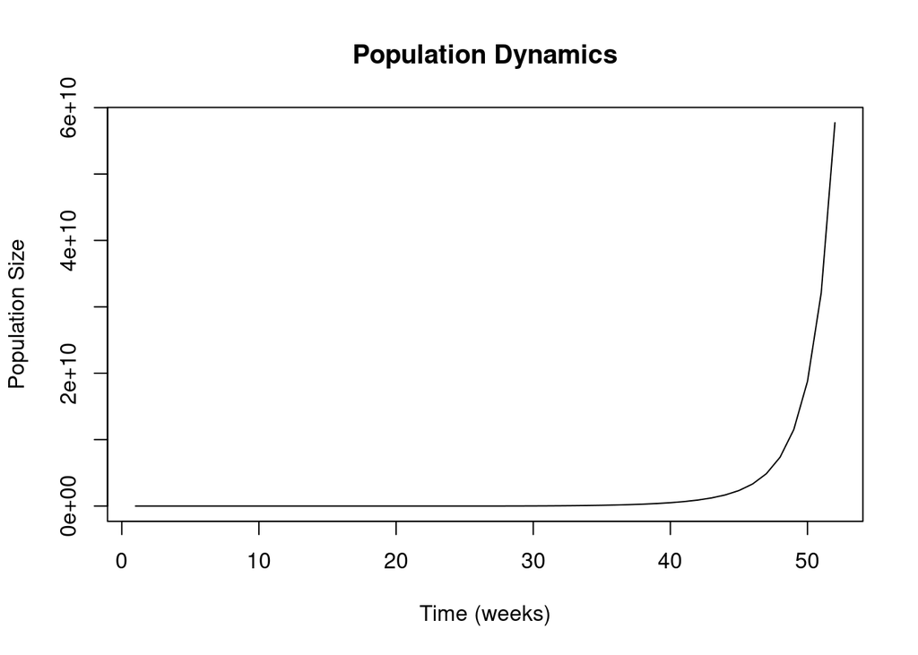

```r
time <- 1:52 # Weeks
N_t <- numeric(length(time))
N_t[1] <- 100 # Initial population

# Parameters
S_base <- 0.9
R_base <- 2
T_opt <- 15
alpha <- 0.1
hatching_success <- 0.5
T <- 15 + 10 * sin(2 * pi * time / 52) # Seasonal temperature variation

for (t in 1:(length(time) - 1)) {
  S_t <- S_base * exp(-alpha * abs(T[t] - T_opt))
  B_t <- N_t[t] * R_base * hatching_success
  N_t[t + 1] <- N_t[t] * S_t + B_t
}

plot(time, N_t, type = "l", xlab = "Time (weeks)", ylab = "Population Size", main = "Population Dynamics")
```

## Conclusion

This document demonstrates a parameterized approach to modeling earthworm populations using environmental and biological parameters. Future refinements may include stochastic elements and data validation.